# Engagement in Focus: How Family, Gender, and Interests Shape Participation

A statistical study on how the new system changes member engagement

Oliver Bisbee, Jayden Luo, Ryan Yu, Junze Du, TUT0111-A

## Introduction

**Wellspring** is a Canadian cancer support organization offering free programs to anyone affected by cancer. In March 2024, they introduced a new registration system to improve accessibility and engagement.

## Introduction: Continue

- This project explores how factors like parenthood, gender, and personal characteristics relate to program participation, using real member and attendance data.
- Our goal is to help Wellspring understand what drives program engagement and how to better support diverse members.

## Scope

- The population of interest includes all individuals who registered with Wellspring and who participated in, or were scheduled to participate in, at least one program between 2023 and early 2024.

## Scope: Continue

- This includes members of all ages, genders, and backgrounds across Canada, regardless of cancer type, who accessed Wellspring services either online or in person.

Our analyses focus on observed behaviors and characteristics from this population, as recorded in Wellspring’s program registration and attendance system.

## Data Summary

This project uses two datasets:

1. **Member Background:** 4,829 members with demographics, cancer history, program interests, and attendance metrics.
2. **Service Deliveries:** 45,254 session records (attended or missed) for 3,780 members between 2023 and 2024.
- Average age is approximately 56 years, and female members are the majority.
- Most members are from Ontario; breast cancer is the most commonly reported cancer type.

## Data Summary: Continue

- Engagement varies widely: median attendance is 2 sessions, while some members attended more than 250.
- Many fields (for example LGBTQ+ status, impairments, and program interests) have high missingness.
- Most sessions were delivered online, and most attendance entries are marked as “Present.”

## Data Summary: Variables

**Variables**:

- **Member Id**: Unique identifier for each member
- **Parent of a child under 18**: Whether the member has a child under 18 (Yes / No / Unknown)
- **Gender**: Self-identified gender of the member
- **Member start year and member start month**

## Data Summary: Variables: Continue

- **Age (years)**: Age of the member
- **Program Interest**: Programs the member is interested in participating in
- **Number of present service deliveries**: Total number of sessions attended
- **Number of absent service deliveries**: Total number of sessions missed

# Research Question 1:

**How do age, number of program interests, and membership duration jointly predict total services attended?**

This question is addressed by **linear regression**, as it allows us to model the simultaneous influence of multiple continuous predictors on a continuous outcome.

### **Method: Multiple Linear Regression**

- **Goal:** Model the relationship between **age, interests, and membership duration** with **total services attended**.
- **Why this method?**
  - Quantifies how each factor affects service attendance.
  - Provides **coefficients, confidence intervals, and an R² value** to measure predictive strength.

## Research Question 1: Method: Continue

- **Implementation**
  - Standard regression techniques in **R** (`lm()` function).
  - Model interpretation: “Holding other factors constant, increasing membership duration by X months increases service attendance by Y.”

## How Variables Affect Attendance

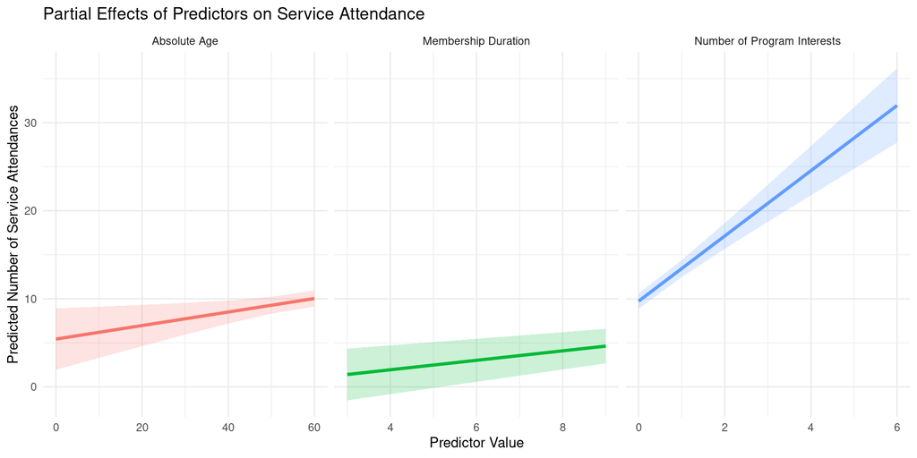

## Results of Data: Continue

- **Outreach Recommendations for Wellspring:**
  - **Targeted Messaging:** Tailor outreach to meet the unique needs of different age groups
  - **Retention Strategies:** Encourage early engagement and maintain long-term member relationships
  - **Program Cross-Promotion:** Leverage multiple program interests to invite members to diverse offerings

## Research Question 2

- **Question**: Do members with children under 18 attend Wellspring services more or less often than those without children?

## Research Question 2: Why It Matters

- **Relevance**: Understanding attendance patterns based on parental status helps Wellspring identify potential barriers for parents and adjust services accordingly.
- Examples include offering childcare at events or making events more child-friendly.

## Research Question 2: Table

Attendance Summary by Parental Status

| Parent Status | Avg. Attended | Total |
| --- | --- | --- |
| No | 70.63 | 6039 |
| Unknown | 38.43 | 31045 |
| Yes | 46.05 | 9219 |

## Research Question 2: Boxplot

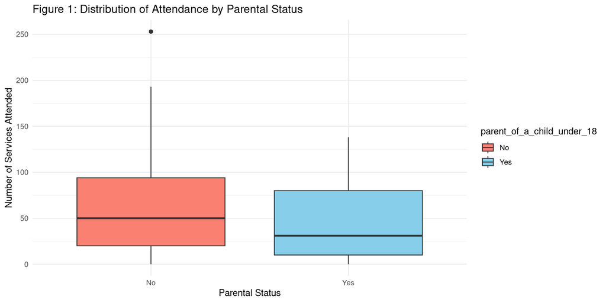

## Research Question 2: Hypothesis Test

- Null hypothesis ($H_0$): There is no difference between the two groups
- Alternative hypothesis ($H_A$): There is a difference between the two groups
- Using a p-value less than 0.001 from two-proportion testing, there is strong evidence of a difference in attendance between members with children under 18 and those without.
- We assume these data are representative.

## Research Question 2: Summary

- The box-and-whisker plot shows that attendance for members with children tends to be lower than for members without children.
- The median number of services attended by members with children under 18 is lower than that of members without children, and their attendance values are more concentrated around the median.
- Limitations: some members chose ‘Unknown’ for parental status; this may affect the variability shown in Table 1.
- Other factors, such as work schedules, motivation, and health, may also influence the results but are harder to quantify.
- Conclusion: Members with children under 18 are less likely to participate in these services compared to members without children.

## Research Question 3

How has the new registration system affected engagement by gender?

## Why this research question?

We chose this research question because:

- It is a two-parameter hypothesis testing question.
- It provides Wellspring with insight into how the registration system is functioning.

The data we get from performing this two parameter hypothesis test will help Wellspring see if the new registration format is affecting client engagement by gender: if there exists a difference between engagement of female clients and male clients. Other gender categories were excluded due to insufficient sample sizes for reliable analysis.

## Why this research question?: Continue

Focused variables by gender:

Appointment schedule summary by gender

| Gender | # | Total present | Total services | Proportion of attended |
| --- | --- | --- | --- | --- |
| Female | 2519 | 25621 | 40115 | 0.6386888 |
| Male | 514 | 3503 | 4955 | 0.7069627 |
| NA | 1794 | 5985 | 10067 | 0.5945167 |

## Graph part 3: Boxplot

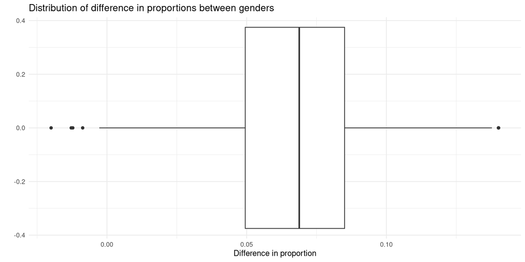

## Data/graph Interpretation

From the simulations we ran:

## Limitations of the Data

- **Limited Variables:**
  - Only a few predictors (age, membership duration, number of program interests) were included.
  - Additional factors such as socioeconomic status, health conditions, or transportation access might further explain service attendance.
- **Data Quality & Completeness:**
  - Potential missing values or measurement errors may impact model reliability.
  - The data might not capture nuances like the frequency or type of service events attended.

## Limitations of the Data: Continue

- **Temporal Considerations:**
  - The analysis is cross-sectional and may not reflect seasonal or recent changes in member behavior.
- **Additional Variables of Interest:**
  - Demographic details (e.g., income, education level) to understand broader member profiles.
  - Psychosocial factors (e.g., motivation, social support) that might influence engagement.
  - Detailed event-specific data (e.g., event type, time, and location) to refine the predictive model.

## Connections & Insights:

- Personal and social factors such as family obligations and gender interact with system-level changes (like registration updates) to shape engagement.
- Structural improvements like system redesign can help. But their impact may vary across subgroups.
- Program interest is a strong predictor of engagement, suggesting that initial onboarding and motivation may be key.

## Recommendations / Next Steps:

- Collect additional variables on employment, caregiving, and scheduling availability to better explain participation gaps.
- Conduct subgroup analyses across other demographics (e.g., age × gender).
- Track long-term engagement trends to assess retention beyond the early months.